# PISA 2012 Data Presentation

## by Nadine Amin

## Dataset Overview

> PISA is a survey of students' skills and knowledge as they approach the end of compulsory education. It focuses on examining how well prepared the students are for life beyond school.

> Around 510,000 students in 65 economies took part in the PISA 2012 assessment of reading, mathematics and science representing about 28 million 15-year-olds globally. Of those economies, 44 took part in an assessment of creative problem solving and 18 in an assessment of financial literacy.

## Investigation Overview

> The goal of this presentation is to show the most important findings of this study. Many variables were examined to see which would have the greatest effects on the students' total scores in maths, reading and science.

## Number of Cellphones, TVs, Computers & Books vs. Total Score

> This violin plots show that students who own three or more cellphones, TVs and computers have a higher chance of getting a higher total score. Moreover, students who have more than 200 books have a greater chance in getting a higher score.

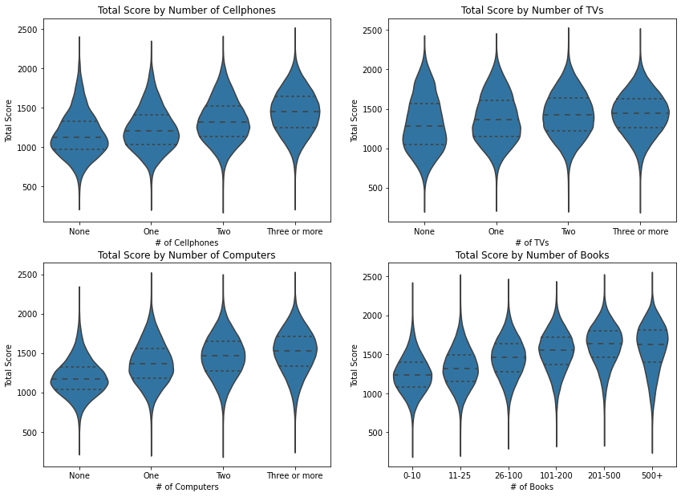

## Parents' Schooling vs. Total Score

> Parents who finished level 3A schooling were the ones with the highest total score average.

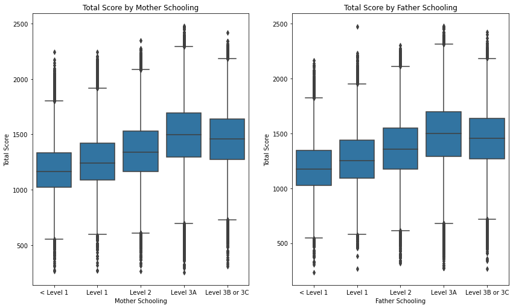

## Parents' Jobs vs. Total Score

> Parents with full time jobs had the highest student mean score.

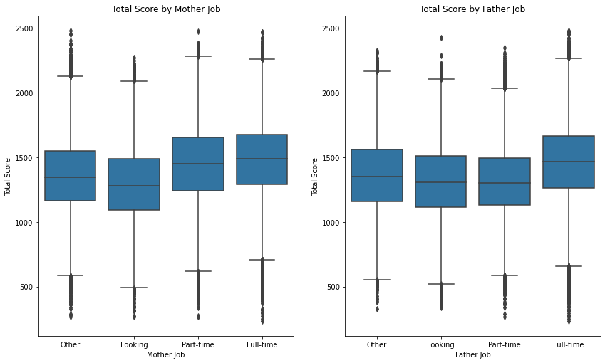

## Homework Study Time vs. Total Score

> The more hours a student spends in studying homework, the higher their chances in getting a higher total score.

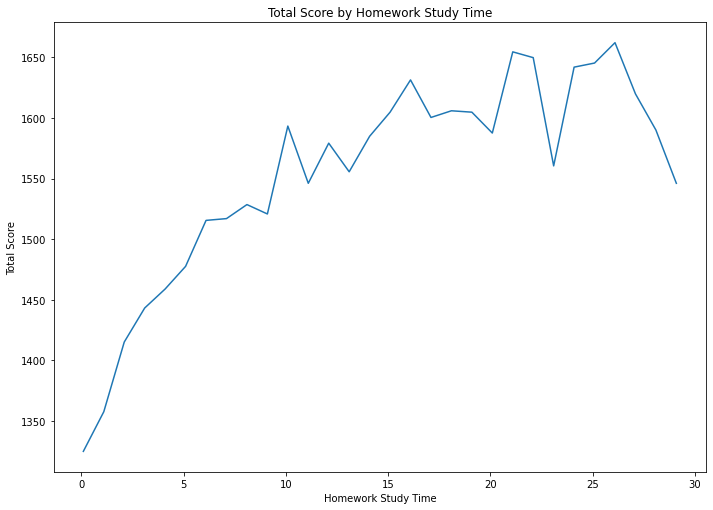

## Number of Cellphones vs. Total Score by Parents' Jobs

> Higher averages of total scores were obtained when the students had three or more cellphones and their parents had full-time jobs.

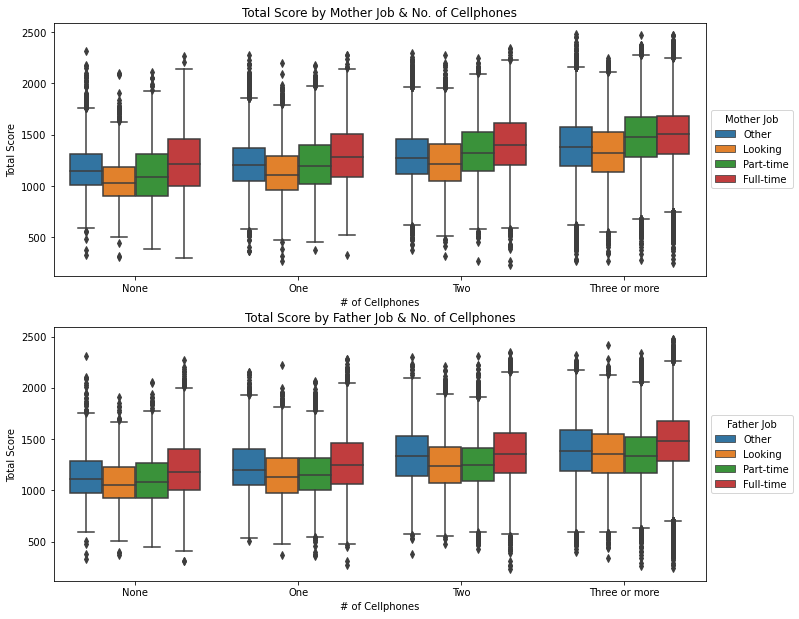